# Artificial Intelligence Spring 99

## Project 4 : Machine Larning Algorithms

## Introduction:

In this project, at first, we inspected data and prepared and normalized it for implementing learning algorithms on it. The next step was to enhance and set hyperparameters of each algorithm to get the maximum accuracy from each model and in the final step we test group learning algorithms to check if they improve our models or not.

## Question:

In order to predict if a customer returns back to a shop, we need to build a model using machine learning algorithms. First we train the model using the given dataset. This data set consists of customer ID, total quantity, total price, country, date, whether the customer came back and purchase count.

Before anything we import libraries that are needed in the project:

```python
import numpy as np
import pandas as pd
import matplotlib.pyplot as plt
import datetime
import sklearn
from sklearn import feature_selection
from sklearn import metrics
from sklearn.preprocessing import MinMaxScaler
from sklearn.model_selection import train_test_split
from sklearn.tree import DecisionTreeClassifier
from sklearn.neighbors import KNeighborsClassifier
from sklearn.linear_model import LogisticRegression
from sklearn.ensemble import BaggingClassifier
from sklearn.ensemble import RandomForestClassifier
from sklearn.ensemble import VotingClassifier
```

Now we read the csv data file and inspect the data and clear it from Null values.

```python
data = pd.read_csv('data.csv')
```

```python
data.head(10)
```

|  | Unnamed: 0 | Customer ID | Total Quantity | Total Price | Country | Date | Is Back | Purchase Count |
| --- | --- | --- | --- | --- | --- | --- | --- | --- |
| 0 | 0 | 16995 | -1 | -1.25 | United Kingdom | 2010-12-02 | No | 1 |
| 1 | 1 | 12552 | 85 | 13.52 | Italy | 2011-10-31 | Yes | 19 |
| 2 | 2 | 13192 | 298 | 15.90 | United Kingdom | 2011-05-18 | Yes | 33 |
| 3 | 3 | 16934 | 399 | 8.30 | United Kingdom | 2011-10-16 | No | 62 |
| 4 | 4 | 14976 | 27 | 11.90 | United Kingdom | 2011-01-17 | Yes | 16 |
| 5 | 5 | 17937 | 564 | 204.00 | United Kingdom | 2010-12-12 | Yes | 13 |
| 6 | 6 | 17601 | 103 | 30.00 | United Kingdom | 2011-04-14 | No | 9 |
| 7 | 7 | 18053 | 302 | 19.80 | United Kingdom | 2011-09-30 | Yes | 20 |
| 8 | 8 | 14089 | 134 | 16.50 | United Kingdom | 2011-10-14 | No | 14 |
| 9 | 9 | 15844 | 134 | 20.28 | United Kingdom | 2011-10-24 | No | 11 |

```python
data.info()
```

```
<class 'pandas.core.frame.DataFrame'>
RangeIndex: 4366 entries, 0 to 4365
Data columns (total 8 columns):
 #   Column          Non-Null Count  Dtype
---  ------          --------------  -----
 0   Unnamed: 0      4366 non-null   int64
 1   Customer ID     4366 non-null   int64
 2   Total Quantity  4366 non-null   int64
 3   Total Price     4366 non-null   float64
 4   Country         4366 non-null   object
 5   Date            4366 non-null   object
 6   Is Back         4366 non-null   object
 7   Purchase Count  4366 non-null   int64
dtypes: float64(1), int64(4), object(3)
memory usage: 273.0+ KB
```

```python
data.isnull().sum()
```

```
Unnamed: 0        0
Customer ID       0
Total Quantity    0
Total Price       0
Country           0
Date              0
Is Back           0
Purchase Count    0
dtype: int64
```

```python
data.describe()
```

|  | Unnamed: 0 | Customer ID | Total Quantity | Total Price | Purchase Count |
| --- | --- | --- | --- | --- | --- |
| count | 4366.000000 | 4366.000000 | 4366.000000 | 4366.000000 | 4366.000000 |
| mean | 2182.500000 | 15299.462666 | 241.991067 | 51.414178 | 23.736372 |
| std | 1260.499967 | 1721.677361 | 463.459092 | 1179.349473 | 23.365366 |
| min | 0.000000 | 12346.000000 | -9360.000000 | -4287.630000 | 0.000000 |
| 25% | 1091.250000 | 13813.250000 | 78.000000 | 8.700000 | 8.000000 |
| 50% | 2182.500000 | 15299.500000 | 152.000000 | 15.800000 | 17.000000 |
| 75% | 3273.750000 | 16776.750000 | 278.000000 | 25.500000 | 30.000000 |
| max | 4365.000000 | 18287.000000 | 12540.000000 | 77183.600000 | 193.000000 |

### Preproccessing:

Then we convert Yes and No's in the dataset to boolean true and falses after that we convert date to day, month and year using to_datetime function.

```python
data['Is Back'] = (data['Is Back'] == 'Yes')
data['Date']= pd.to_datetime(data['Date'])
data['Year'] = data['Date'].dt.year
data['Month'] = data['Date'].dt.month
data['Day'] = data['Date'].dt.day
```

```python
data.Country.value_counts()
```

```
United Kingdom          3946
Germany                   95
France                    86
Spain                     29
Belgium                   24
Switzerland               19
Portugal                  19
Italy                     15
Finland                   12
Norway                    10
Netherlands                9
Australia                  9
Austria                    9
Channel Islands            9
Denmark                    8
Japan                      8
Sweden                     8
Cyprus                     7
Poland                     6
Greece                     4
Canada                     4
Unspecified                4
Israel                     4
USA                        4
EIRE                       3
United Arab Emirates       2
Bahrain                    2
Malta                      2
RSA                        1
Lithuania                  1
Czech Republic             1
Iceland                    1
Lebanon                    1
Saudi Arabia               1
Brazil                     1
European Community         1
Singapore                  1
Name: Country, dtype: int64
```

Now we modify the data by erasing rows with invalid values and useless columns like customer id and convert country column using one hot encoding. If we want to use categorical data we should convert it to numeric data. One approach is to use One Hot encoding that adds a column for each word and determins that category by 0 and 1 values but this method have a negative point which is that we have to add one column for each word available so we will need a lot of memory so we can't use it for many columns or a column that has a lot of possible values. Other approach is to use label encoding in which each category will be labeled with an integer bigger than 0 but the problem is that different categories will get different numeric numbers and the model would be trained based on this value which is not desired so we use one hot encoding in this project.

```python
dataframe = data.loc[:, ['Total Quantity', 'Total Price', 'Country', 'Year', 'Month', 'Day', 'Purchase Count', 'Is Back']]
dataframe = pd.get_dummies(dataframe, prefix = 'Country')
dataframe = dataframe.loc[(dataframe['Total Quantity'] > 0)]
dataframe = dataframe.loc[(dataframe['Total Price'] >= 0)]
dataframe = dataframe.loc[(dataframe['Purchase Count'] >= 0)]
dataframe = dataframe.loc[(dataframe['Year'] >= 0)]
dataframe = dataframe.loc[(dataframe['Month'] > 0) & (dataframe['Month'] <= 12)]
dataframe = dataframe.loc[(dataframe['Day'] > 0) & (dataframe['Day'] <= 31)]
dataframe
```

|  | Total Quantity | Total Price | Year | Month | Day | Purchase Count | Is Back | Country_Australia | Country_Austria | Country_Bahrain | ... | Country_RSA | Country_Saudi Arabia | Country_Singapore | Country_Spain | Country_Sweden | Country_Switzerland | Country_USA | Country_United Arab Emirates | Country_United Kingdom | Country_Unspecified |
| --- | --- | --- | --- | --- | --- | --- | --- | --- | --- | --- | --- | --- | --- | --- | --- | --- | --- | --- | --- | --- | --- |
| 1 | 85 | 13.52 | 2011 | 10 | 31 | 19 | True | 0 | 0 | 0 | ... | 0 | 0 | 0 | 0 | 0 | 0 | 0 | 0 | 0 | 0 |
| 2 | 298 | 15.90 | 2011 | 5 | 18 | 33 | True | 0 | 0 | 0 | ... | 0 | 0 | 0 | 0 | 0 | 0 | 0 | 0 | 1 | 0 |
| 3 | 399 | 8.30 | 2011 | 10 | 16 | 62 | False | 0 | 0 | 0 | ... | 0 | 0 | 0 | 0 | 0 | 0 | 0 | 0 | 1 | 0 |
| 4 | 27 | 11.90 | 2011 | 1 | 17 | 16 | True | 0 | 0 | 0 | ... | 0 | 0 | 0 | 0 | 0 | 0 | 0 | 0 | 1 | 0 |
| 5 | 564 | 204.00 | 2010 | 12 | 12 | 13 | True | 0 | 0 | 0 | ... | 0 | 0 | 0 | 0 | 0 | 0 | 0 | 0 | 1 | 0 |
| ... | ... | ... | ... | ... | ... | ... | ... | ... | ... | ... | ... | ... | ... | ... | ... | ... | ... | ... | ... | ... | ... |
| 4361 | 58 | 20.40 | 2011 | 3 | 20 | 5 | False | 0 | 0 | 0 | ... | 0 | 0 | 0 | 0 | 0 | 0 | 0 | 0 | 1 | 0 |
| 4362 | 582 | 5.04 | 2011 | 10 | 11 | 62 | True | 0 | 0 | 0 | ... | 0 | 0 | 0 | 0 | 0 | 1 | 0 | 0 | 0 | 0 |
| 4363 | 231 | 15.00 | 2011 | 7 | 25 | 16 | True | 0 | 0 | 0 | ... | 0 | 0 | 0 | 0 | 0 | 0 | 0 | 0 | 1 | 0 |
| 4364 | 57 | 17.70 | 2011 | 5 | 26 | 8 | True | 0 | 0 | 0 | ... | 0 | 0 | 0 | 0 | 0 | 0 | 0 | 0 | 1 | 0 |
| 4365 | 44 | 14.85 | 2011 | 3 | 14 | 5 | False | 0 | 0 | 0 | ... | 0 | 0 | 0 | 0 | 0 | 0 | 0 | 0 | 1 | 0 |

4184 rows × 44 columns

The final step of data preproccessing is scaling usefull values using Minmaxscaler. In most of the machine learning algorithms, we have to scale data in order to prevent one big number impacting the model more than it is supposed to. In this project MinMaxScaler is used which reduces minimum value of each column from all values in each column divide it by max - min so that all values are between 0 and 1.

```python
MMScaler = MinMaxScaler()
dataframe[['Total Quantity', 'Total Price', 'Year', 'Month', 'Day', 'Purchase Count']] = MMScaler.fit_transform(dataframe[['Total Quantity', 'Total Price', 'Year', 'Month', 'Day', 'Purchase Count']])
dataframe
```

|  | Total Quantity | Total Price | Year | Month | Day | Purchase Count | Is Back | Country_Australia | Country_Austria | Country_Bahrain | ... | Country_RSA | Country_Saudi Arabia | Country_Singapore | Country_Spain | Country_Sweden | Country_Switzerland | Country_USA | Country_United Arab Emirates | Country_United Kingdom | Country_Unspecified |
| --- | --- | --- | --- | --- | --- | --- | --- | --- | --- | --- | --- | --- | --- | --- | --- | --- | --- | --- | --- | --- | --- |
| 1 | 0.006699 | 0.002747 | 1.0 | 0.818182 | 1.000000 | 0.098446 | True | 0 | 0 | 0 | ... | 0 | 0 | 0 | 0 | 0 | 0 | 0 | 0 | 0 | 0 |
| 2 | 0.023686 | 0.003231 | 1.0 | 0.363636 | 0.566667 | 0.170984 | True | 0 | 0 | 0 | ... | 0 | 0 | 0 | 0 | 0 | 0 | 0 | 0 | 1 | 0 |
| 3 | 0.031741 | 0.001686 | 1.0 | 0.818182 | 0.500000 | 0.321244 | False | 0 | 0 | 0 | ... | 0 | 0 | 0 | 0 | 0 | 0 | 0 | 0 | 1 | 0 |
| 4 | 0.002074 | 0.002418 | 1.0 | 0.000000 | 0.533333 | 0.082902 | True | 0 | 0 | 0 | ... | 0 | 0 | 0 | 0 | 0 | 0 | 0 | 0 | 1 | 0 |
| 5 | 0.044900 | 0.041451 | 0.0 | 1.000000 | 0.366667 | 0.067358 | True | 0 | 0 | 0 | ... | 0 | 0 | 0 | 0 | 0 | 0 | 0 | 0 | 1 | 0 |
| ... | ... | ... | ... | ... | ... | ... | ... | ... | ... | ... | ... | ... | ... | ... | ... | ... | ... | ... | ... | ... | ... |
| 4361 | 0.004546 | 0.004145 | 1.0 | 0.181818 | 0.633333 | 0.025907 | False | 0 | 0 | 0 | ... | 0 | 0 | 0 | 0 | 0 | 0 | 0 | 0 | 1 | 0 |
| 4362 | 0.046335 | 0.001024 | 1.0 | 0.818182 | 0.333333 | 0.321244 | True | 0 | 0 | 0 | ... | 0 | 0 | 0 | 0 | 0 | 1 | 0 | 0 | 0 | 0 |
| 4363 | 0.018343 | 0.003048 | 1.0 | 0.545455 | 0.800000 | 0.082902 | True | 0 | 0 | 0 | ... | 0 | 0 | 0 | 0 | 0 | 0 | 0 | 0 | 1 | 0 |
| 4364 | 0.004466 | 0.003596 | 1.0 | 0.363636 | 0.833333 | 0.041451 | True | 0 | 0 | 0 | ... | 0 | 0 | 0 | 0 | 0 | 0 | 0 | 0 | 1 | 0 |
| 4365 | 0.003429 | 0.003017 | 1.0 | 0.181818 | 0.433333 | 0.025907 | False | 0 | 0 | 0 | ... | 0 | 0 | 0 | 0 | 0 | 0 | 0 | 0 | 1 | 0 |

4184 rows × 44 columns

In machine learning we use parameter of information gain which is the amount of information gained about a random variable from observing another random variable. We calculate information gain of each feature about Is Back attribute. It is clear that some feature are more realated such as month and year while some have low information gain and doesn't help us thus they should be dropped from dataset.

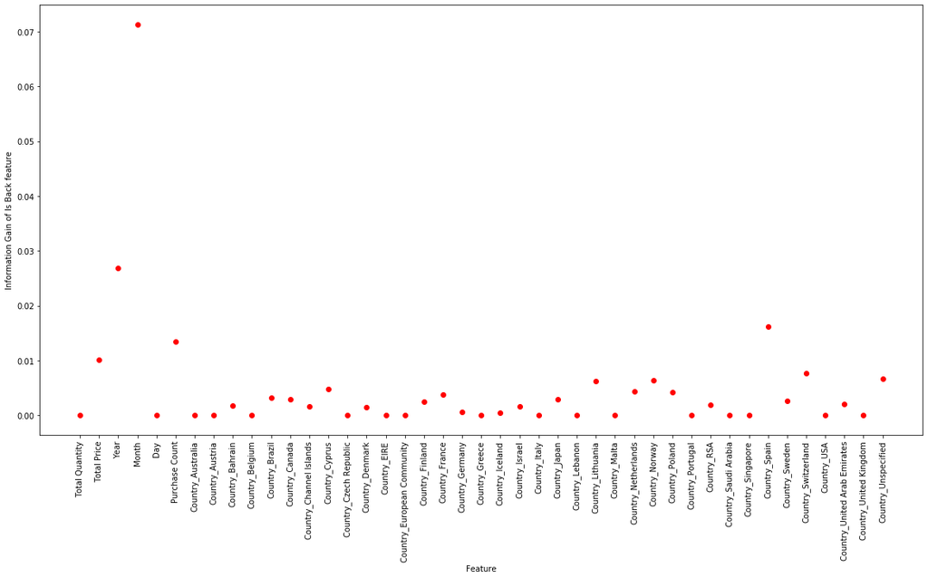

```python
dataframe2 = dataframe.drop(columns = ['Is Back'])
features = list(dataframe2.columns.values)
plt.figure(figsize = (20,10))
plt.plot(sklearn.feature_selection.mutual_info_classif(dataframe2, dataframe['Is Back']), 'ro')
plt.xticks(np.arange(len(features)), features, rotation = 90)
plt.xlabel('Feature')
plt.ylabel('Information Gain of Is Back feature')
plt.show()
```

Now we split data to test and train with 20 and 80 percentages:

```python
tsize = 0.2
seed = 7
X_train, X_test, y_train, y_test = train_test_split(dataframe2, dataframe['Is Back'], test_size = tsize, random_state = seed)
X_train.shape, y_train.shape, X_test.shape, y_test.shape
```

```
((3347, 43), (3347,), (837, 43), (837,))
```

### Decision Tree:

After the preproccessing stage we start implementing learning algorithms. First one is decision tree. A decision tree is a decision support tool that uses a tree-like model of decisions and their possible consequences, including chance event outcomes, resource costs, and utility. It is one way to display an algorithm that only contains conditional control statements. The best way to show the effect of depth is to show metrics plot. It could be seen that when the depth is increased more than a threshold overfitting happens because the leaves of the tree will contain less nodes and the model will be trained to give better answers for the trained data but worse for test data. The accuracy starts to decrease from depth of 4. The depth I chose is 5 because all metrics are high enough.

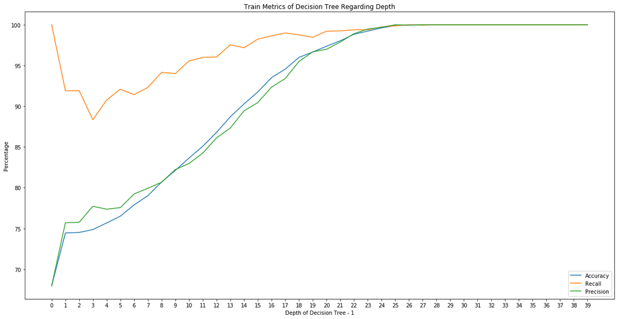

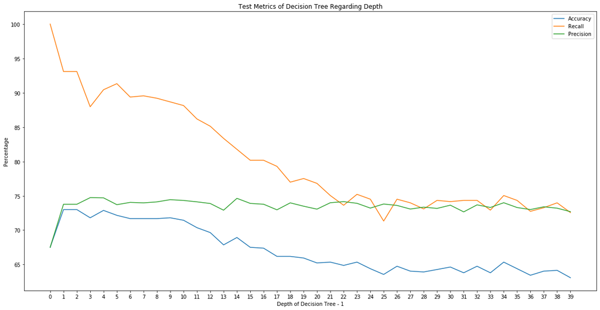

```python
testAccuracy = []
trainAccuracy = []
testPrecision = []
trainPrecision = []
testRecall = []
trainRecall = []
for depth in range(1, 41):
    Dclassifier = DecisionTreeClassifier(max_depth = depth)
    Dclassifier = Dclassifier.fit(X_train, y_train)
    trainAccuracy.append(metrics.accuracy_score(y_train, Dclassifier.predict(X_train)) * 100)
    testAccuracy.append(metrics.accuracy_score(y_test, Dclassifier.predict(X_test)) * 100)
    trainPrecision.append(metrics.precision_score(y_train, Dclassifier.predict(X_train)) * 100)
    testPrecision.append(metrics.precision_score(y_test, Dclassifier.predict(X_test)) * 100)
    trainRecall.append(metrics.recall_score(y_train, Dclassifier.predict(X_train)) * 100)
    testRecall.append(metrics.recall_score(y_test, Dclassifier.predict(X_test)) * 100)

plt.figure(figsize = (20,10))
plt.plot(trainAccuracy , label = 'Accuracy')
plt.plot(trainRecall, label = 'Recall')
plt.plot(trainPrecision, label = 'Precision')
plt.xticks(np.arange(40))
plt.title('Train Metrics of Decision Tree Regarding Depth')
plt.xlabel('Depth of Decision Tree - 1')
plt.ylabel('Percentage')
plt.legend()
plt.show()

plt.figure(figsize = (20,10))
plt.plot(testAccuracy, label = 'Accuracy')
plt.plot(testRecall, label = 'Recall')
plt.plot(testPrecision, label = 'Precision')
plt.xticks(np.arange(40))
plt.title('Test Metrics of Decision Tree Regarding Depth')
plt.xlabel('Depth of Decision Tree - 1')
plt.ylabel('Percentage')
plt.legend()
plt.show()
```

```python
Dclassifier = DecisionTreeClassifier(max_depth = 5)
Dclassifier = Dclassifier.fit(X_train, y_train)
print("Accuracy :", metrics.accuracy_score(y_test, Dclassifier.predict(X_test)))
print("Precision :", metrics.precision_score(y_test, Dclassifier.predict(X_test)))
print("Recall :", metrics.recall_score(y_test, Dclassifier.predict(X_test)))
```

```
Accuracy : 0.7287933094384708
Precision : 0.7470760233918129
Recall : 0.904424778761062
```

### KNN:

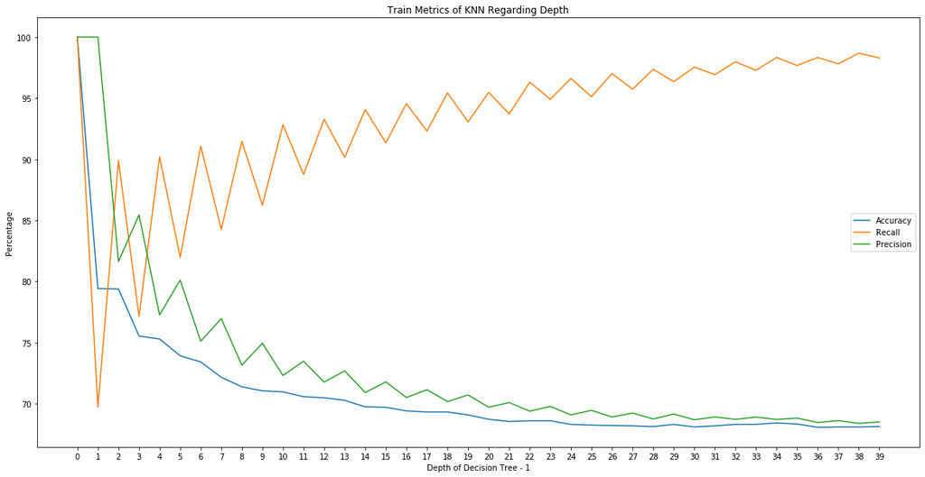

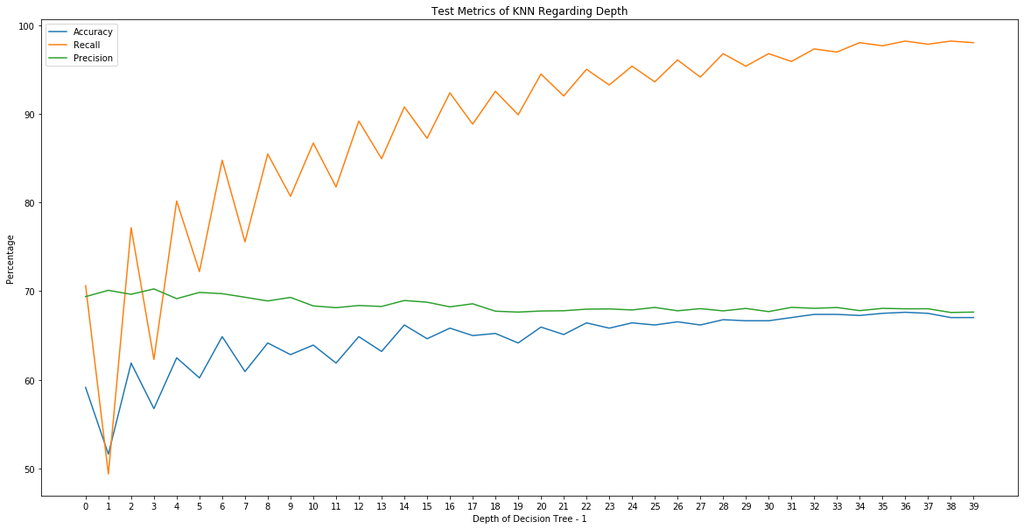

```python
testAccuracy = []
trainAccuracy = []
testPrecision = []
trainPrecision = []
testRecall = []
trainRecall = []
for neighbors in range(1, 41):
    KNNclassifier = KNeighborsClassifier(n_neighbors = neighbors)
    KNNclassifier = KNNclassifier.fit(X_train, y_train)
    trainAccuracy.append(metrics.accuracy_score(y_train, KNNclassifier.predict(X_train)) * 100)
    testAccuracy.append(metrics.accuracy_score(y_test, KNNclassifier.predict(X_test)) * 100)
    trainPrecision.append(metrics.precision_score(y_train, KNNclassifier.predict(X_train)) * 100)
    testPrecision.append(metrics.precision_score(y_test, KNNclassifier.predict(X_test)) * 100)
    trainRecall.append(metrics.recall_score(y_train, KNNclassifier.predict(X_train)) * 100)
    testRecall.append(metrics.recall_score(y_test, KNNclassifier.predict(X_test)) * 100)

plt.figure(figsize = (20,10))
plt.plot(trainAccuracy, label = 'Accuracy')
plt.plot(trainRecall, label = 'Recall')
plt.plot(trainPrecision, label = 'Precision')
plt.xticks(np.arange(40))
plt.title('Train Metrics of KNN Regarding Depth')
plt.xlabel('Depth of Decision Tree - 1')
plt.ylabel('Percentage')
plt.legend()
plt.show()

plt.figure(figsize = (20,10))
plt.plot(testAccuracy, label = 'Accuracy')
plt.plot(testRecall, label = 'Recall')
plt.plot(testPrecision, label = 'Precision')
plt.xticks(np.arange(40))
plt.title('Test Metrics of KNN Regarding Depth')
plt.xlabel('Depth of Decision Tree - 1')
plt.ylabel('Percentage')
plt.legend()
plt.show()
```

```python
KNNclassifier = KNeighborsClassifier(n_neighbors = 16)
KNNclassifierr = KNNclassifier.fit(X_train, y_train)
print("Accuracy :", metrics.accuracy_score(y_test, KNNclassifier.predict(X_test)))
print("Precision :", metrics.precision_score(y_test, KNNclassifier.predict(X_test)))
print("Recall :", metrics.recall_score(y_test, KNNclassifier.predict(X_test)))
```

```
Accuracy : 0.6463560334528077
Precision : 0.6875871687587168
Recall : 0.8725663716814159
```

### Logistic Regression:

Logistic regression is a statistical model that in its basic form uses a logistic function to model a binary dependent variable, although many more complex extensions exist. In regression analysis, logistic regression is estimating the parameters of a logistic model. The result is accurate enough so there is no need to modify it.

```python
seed = 7
LRclassifier = LogisticRegression(random_state = seed)
LRclassifier = LRclassifier.fit(X_train,y_train)
print('Accuracy :', metrics.accuracy_score(y_test, LRclassifier.predict(X_test)))
print('Precision :', metrics.precision_score(y_test, LRclassifier.predict(X_test)))
print('Recall :', metrics.recall_score(y_test, LRclassifier.predict(X_test)))
```

```
Accuracy : 0.6798088410991637
Precision : 0.6787003610108303
Recall : 0.9982300884955753
```

### Bagging:

```python
seed = 7
DTCBaggingclassifier = BaggingClassifier(base_estimator = Dclassifier, max_features = 0.5, max_samples = 0.5, n_estimators = 10, random_state = seed)
DTCBaggingclassifier = DTCBaggingclassifier.fit(X_train,y_train)
print('Accuracy :', metrics.accuracy_score(y_test, DTCBaggingclassifier.predict(X_test)))
print('Precision :', metrics.precision_score(y_test, DTCBaggingclassifier.predict(X_test)))
print('Recall :', metrics.recall_score(y_test, DTCBaggingclassifier.predict(X_test)))
```

```
Accuracy : 0.6571087216248507
Precision : 0.6863270777479893
Recall : 0.9061946902654867
```

```python
seed = 7
KNNBaggingclassifier = BaggingClassifier(base_estimator = KNNclassifier, max_features = 0.5, max_samples = 0.5, n_estimators = 20, random_state = seed)
KNNBaggingclassifier = KNNBaggingclassifier.fit(X_train,y_train)
print('Accuracy :', metrics.accuracy_score(y_test, KNNBaggingclassifier.predict(X_test)))
print('Precision :', metrics.precision_score(y_test, KNNBaggingclassifier.predict(X_test)))
print('Recall :', metrics.recall_score(y_test, KNNBaggingclassifier.predict(X_test)))
```

```
Accuracy : 0.6738351254480287
Precision : 0.6746411483253588
Recall : 0.9982300884955753
```

### Random Forest:

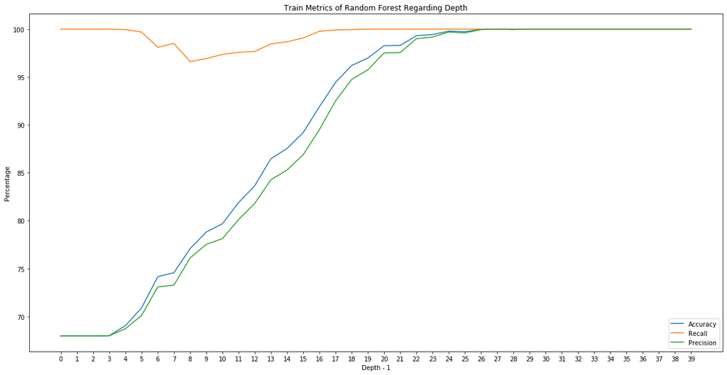

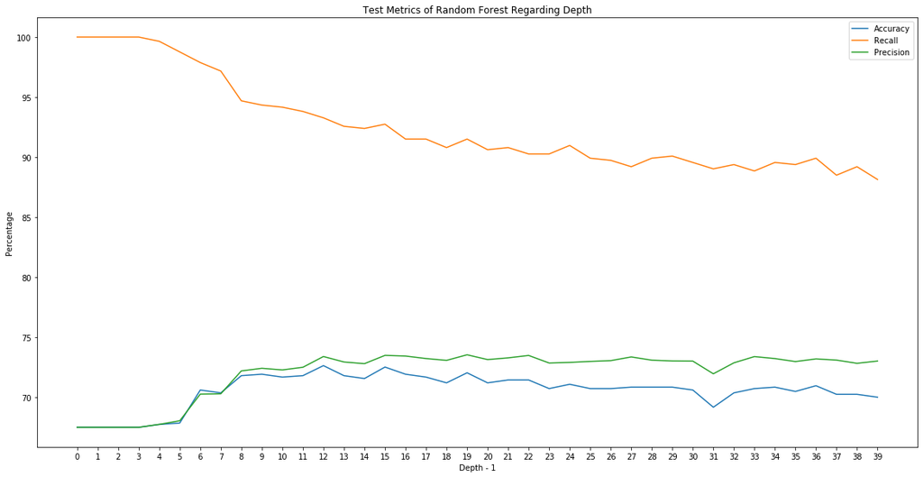

```python
testAccuracy = []
trainAccuracy = []
testPrecision = []
trainPrecision = []
testRecall = []
trainRecall = []
for depth in range(1, 41):
    RFclassifier = RandomForestClassifier(max_depth = depth)
    RFclassifier = RFclassifier.fit(X_train, y_train)
    trainAccuracy.append(metrics.accuracy_score(y_train, RFclassifier.predict(X_train)) * 100)
    testAccuracy.append(metrics.accuracy_score(y_test, RFclassifier.predict(X_test)) * 100)
    trainPrecision.append(metrics.precision_score(y_train, RFclassifier.predict(X_train)) * 100)
    testPrecision.append(metrics.precision_score(y_test, RFclassifier.predict(X_test)) * 100)
    trainRecall.append(metrics.recall_score(y_train, RFclassifier.predict(X_train)) * 100)
    testRecall.append(metrics.recall_score(y_test, RFclassifier.predict(X_test)) * 100)

plt.figure(figsize = (20,10))
plt.plot(trainAccuracy, label = 'Accuracy')
plt.plot(trainRecall, label = 'Recall')
plt.plot(trainPrecision, label = 'Precision')
plt.xticks(np.arange(40))
plt.title('Train Metrics of Random Forest Regarding Depth')
plt.xlabel('Depth - 1')
plt.ylabel('Percentage')
plt.legend()
plt.show()

plt.figure(figsize = (20,10))
plt.plot(testAccuracy, label = 'Accuracy')
plt.plot(testRecall, label = 'Recall')
plt.plot(testPrecision, label = 'Precision')
plt.xticks(np.arange(40))
plt.title('Test Metrics of Random Forest Regarding Depth')
plt.xlabel('Depth - 1')
plt.ylabel('Percentage')
plt.legend()
plt.show()
```

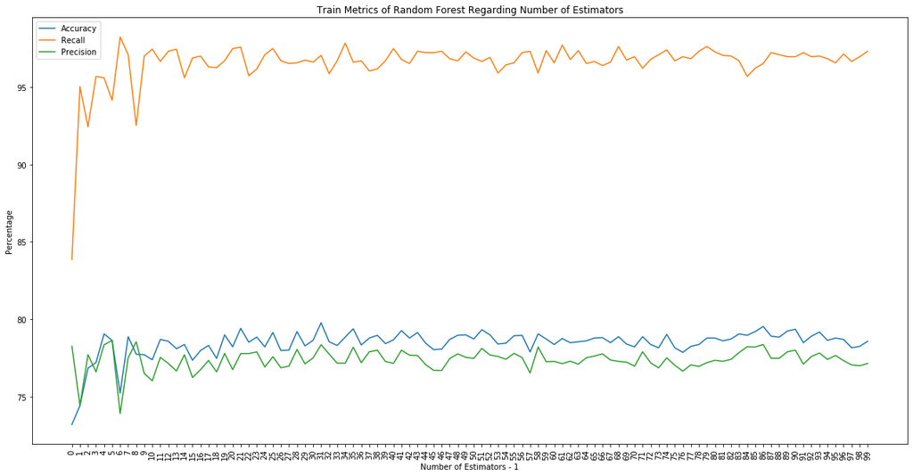

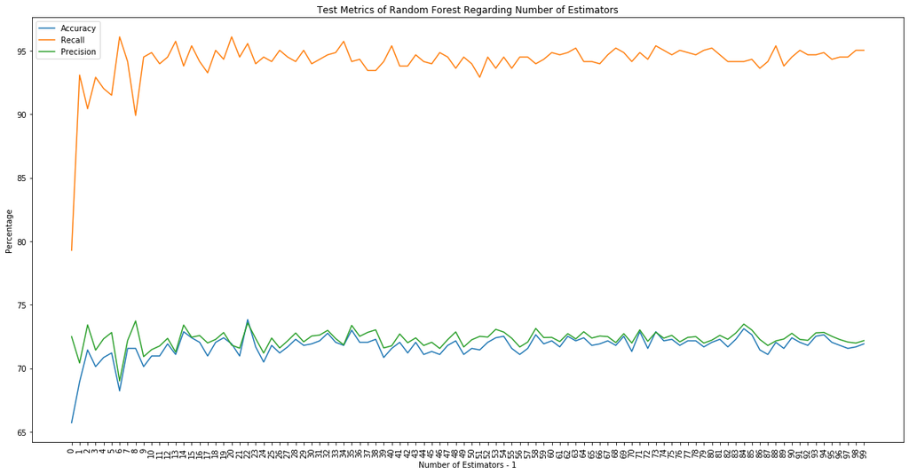

```python
testAccuracy = []
trainAccuracy = []
testPrecision = []
trainPrecision = []
testRecall = []
trainRecall = []
for number in range(1, 101):
    RFclassifier = RandomForestClassifier(max_depth = 10, n_estimators = number)
    RFclassifier = RFclassifier.fit(X_train, y_train)
    trainAccuracy.append(metrics.accuracy_score(y_train, RFclassifier.predict(X_train)) * 100)
    testAccuracy.append(metrics.accuracy_score(y_test, RFclassifier.predict(X_test)) * 100)
    trainPrecision.append(metrics.precision_score(y_train, RFclassifier.predict(X_train)) * 100)
    testPrecision.append(metrics.precision_score(y_test, RFclassifier.predict(X_test)) * 100)
    trainRecall.append(metrics.recall_score(y_train, RFclassifier.predict(X_train)) * 100)
    testRecall.append(metrics.recall_score(y_test, RFclassifier.predict(X_test)) * 100)

plt.figure(figsize = (20,10))
plt.plot(trainAccuracy, label = 'Accuracy')
plt.plot(trainRecall, label = 'Recall')
plt.plot(trainPrecision, label = 'Precision')
plt.xticks(np.arange(100), rotation = 90)
plt.title('Train Metrics of Random Forest Regarding Number of Estimators')
plt.xlabel('Number of Estimators - 1')
plt.ylabel('Percentage')
plt.legend()
plt.show()

plt.figure(figsize = (20,10))
plt.plot(testAccuracy, label = 'Accuracy')
plt.plot(testRecall, label = 'Recall')
plt.plot(testPrecision, label = 'Precision')
plt.xticks(np.arange(100), rotation = 90)
plt.title('Test Metrics of Random Forest Regarding Number of Estimators')
plt.xlabel('Number of Estimators - 1')
plt.ylabel('Percentage')
plt.legend()
plt.show()
```

```python
seed = 7
RFclassifier = RandomForestClassifier(max_depth = 20, n_estimators = 36, random_state = seed)
RFclassifier = RFclassifier.fit(X_train,y_train)
print('Accuracy :', metrics.accuracy_score(y_test, RFclassifier.predict(X_test)))
print('Precision :', metrics.precision_score(y_test, RFclassifier.predict(X_test)))
print('Recall :', metrics.recall_score(y_test, RFclassifier.predict(X_test)))
```

```
Accuracy : 0.7192353643966547
Precision : 0.7370689655172413
Recall : 0.9079646017699115
```

### Impact of Bagging on overfitting and Bootstrapping:

We can see that bagging decreases the effect of overfitting. Bagging takes the advantage of ensemble learning multiple weak learners and it helps to reduce variance and as a result of that helps us avoid overfitting. Bootstrapping is a sampling technique in which it chooses k samples from n samples with replacement and the we run algorithm on each of these samples. Bootstrapping improves bias and reduces variance. If we have done sampling without replacement the samples drawn will be dependent on the previous ones randomness of our data would be destroyed.

```python
Dclassifier = DecisionTreeClassifier(max_depth = 25)
Dclassifier = Dclassifier.fit(X_train, y_train)
print("Without Bagging")
print("Accuracy :", metrics.accuracy_score(y_test, Dclassifier.predict(X_test)))
print("Precision :", metrics.precision_score(y_test, Dclassifier.predict(X_test)))
print("Recall :", metrics.recall_score(y_test, Dclassifier.predict(X_test)))
seed = 7
DTCBaggingclassifier = BaggingClassifier(base_estimator = Dclassifier, max_features = 0.5, max_samples = 0.5, n_estimators = 10, random_state = seed)
DTCBaggingclassifier = DTCBaggingclassifier.fit(X_train,y_train)
print("With Bagging")
print('Accuracy :', metrics.accuracy_score(y_test, DTCBaggingclassifier.predict(X_test)))
print('Precision :', metrics.precision_score(y_test, DTCBaggingclassifier.predict(X_test)))
print('Recall :', metrics.recall_score(y_test, DTCBaggingclassifier.predict(X_test)))
```

```
Without Bagging
Accuracy : 0.6415770609318996
Precision : 0.7328646748681898
Recall : 0.7380530973451327
With Bagging
Accuracy : 0.6583034647550776
Precision : 0.687248322147651
Recall : 0.9061946902654867
```

### Hard Voting:

It is the methofd that predicts which learning algorithm would be more succesfull and chooses the result of that algorithm.

```python
votingClassifier = VotingClassifier(estimators = [('dtc', Dclassifier), ('knn', KNNclassifier), ('logreg', LRclassifier)], voting = 'hard').fit(X_train, y_train)
votingClassifier = votingClassifier.fit(X_train, y_train)
print('Accuracy :', metrics.accuracy_score(y_test, votingClassifier.predict(X_test)))
print('Precision :', metrics.precision_score(y_test, votingClassifier.predict(X_test)))
print('Recall :', metrics.recall_score(y_test, votingClassifier.predict(X_test)))
```

```
Accuracy : 0.6750298685782556
Precision : 0.6875800256081946
Recall : 0.9504424778761061
```